# aaa

## Selection on observables

The main idea in (LaLonde 1986) and (Dehejia and Wahba 1999) is to replace the experimental control group with a control group which is taken from a survey. This means that we go from an experimental setting to an observational one (one where the potential outcomes cannot be expected to be independent from the treatment). The goal is to see whether observational methods can get near to the experimental estimates. To construct this database we keep only the treated from the experimental data and take as control the Current Population Survey (CPS).

```r
cps_lalonde <- lalonde::cps_controls2
obs_df <- exp_df %>%
  filter(treat == 1) %>%
  bind_rows(cps_lalonde) %>%
  dplyr::select(-data_id)
```

To be able to identify treatment effects we still need to assume selection on observables: $A1': (Y(1)_i, Y(0)_i) \perp D_i | X_i$. That is, the distribution of the potential outcomes now can vary for individuals with different treatments as long as they have different covariates, however, for those with the same covariates, the potential outcomes still have to be independent from treatment. Let us define an ATE which might depend on $X_i$ and denote it as $ATE(X_i)$ (also called CATE)

$$ATE(X_i) = \mathbb{E}[Y(1)_i| X_i] - \mathbb{E}[Y(0)_i |X_i].$$
To retrieve the ATE we can just take $\mathbb{E}[ATE(X_i)]$. By A1’ we have that

$$ATE(X_i) = \mathbb{E}[Y_i | D_i = 1, X_i] - \mathbb{E}[Y_i | D_i = 0,
X_i].$$

By specifying some regression $m_1(X_i) = \mathbb{E}[Y_i | D_i = 1, X_i]$ and $m_0(X_i) = \mathbb{E}[Y_i | D_i = 0, X_i]$ and estimating the regressions we get what is sometimes called a **direct estimator**. If the ATE is constant across the support of $X_i$, then $ATE = ATE(X_i)$. One case in which this is true is under the assumption that $\mathbb{E}[Y_i | D_i, X_i] = \delta_0 + \tau D_i + \delta_1' X_i$. Under this linearity assumption, the ATE can be estimated by OLS

```r
m1obs <- lm(re78 ~ treat + poly(age,2) + education + black + hispanic + nodegree, obs_df)
lmtest::coeftest(m1obs, vcov=sandwich::vcovHC(m1obs, type='HC2'))[2,]
```

```
##      Estimate    Std. Error       t value      Pr(>|t|)
## -2.340814e+03  5.453899e+02 -4.292000e+00  1.834070e-05
```

we see that the estimated ATE is very negative. This is because the treatment and the control are hardly comparable. The treatment is formed by disadvantaged individuals and the control by a representative sample of the US population. In the absence of treatment disadvantaged individuals would already have much lower earnings. One way of allowing for $ATE(X_i)$ to vary with $X_i$ is to assume two different linear regressions for treated and untreated. This is equivalent to specifying one linear regression with an interaction term.

$$\mathbb{E}[Y_i | D_i, X_i] = \gamma_0 + \gamma_1 D_i + \gamma_2' X_i
+ \gamma_3' (D_i X_i).$$
In this case $ATE(X_i) = \gamma_1 + \gamma_3' X_i$ and $ATE = \gamma_1 + \gamma_3' \mathbb{E}[X_i]$. And easier way to estimate the ATE (under the linearity assumption) is to reparametrize the above specification and run

$$Y_i = \gamma_0^* + \gamma_1^* D_i + \gamma_2^{*'} X_i +
\gamma_3^{*'} (D_i \tilde{X}_i) + \eta_i$$

where $\tilde{X}_i$ is $X_i$ minus its mean. Then it can be showed that $ATE = \gamma_1^*$.

```r
Y <- obs_df$re78
D <- obs_df$treat
X <- dplyr::select(obs_df, c("age", "education", "black", "hispanic", "nodegree"))
X$agesq <- X$age^2
DXc <- D*scale(X, center = TRUE, scale = FALSE)
colnames(DXc) <- paste("dx",names(X), sep = "_")
df3 <- cbind(Y = Y,D,X,DXc)
m3obs <- lm(Y ~., df3)
lmtest::coeftest(m3obs, vcov=sandwich::vcovHC(m3obs, type='HC2'))[2,]
```

```
##      Estimate    Std. Error       t value      Pr(>|t|)
## -2.921629e+03  9.501247e+02 -3.074996e+00  2.126508e-03
```

## Inverse propensity score weighting (IPW)

When the dimension of $X_i$ is large it is handy to define the propensity score:

$$p(X_i) = \mathbb{P}(D_i = 1 | X_i),$$

i.e. the probability of being treated given the covariates. This is useful thanks to two results in Rosenbaum & Rubin(1983). Mainly that if selection on observables holds and $A2: 0< p(X_i) < 1$ a.s. (Common Suppport), then $(Y(1)_i, Y(0)_i) \perp D_i | p(X_i)$, i.e. it is enough to control for $p(X_i)$. Also, if $p(X_i)$ is the propensity score then $X_i \perp D_i | p(X_i)$, so the distribution of $X_i$ does not vary across treatment status given the propensity score. One can show that under A1’ and A2

$$\tau_0 = \mathbb{E}\biggl(\frac{D_i Y_i}{p(X_i)} - \frac{(1-D_i)Y_i}{1 -
p(X_i)} \biggr).$$
However, $p(X_i)$ is generally unknown and has to be estimated. To this end we can impose a parametric model. A popular choice is

$$p(X_i) = G(X_i' \beta_0),$$
where $G(\cdot)$ is the c.d.f of a distribution which is symmetric around 0 and $\beta_0$ is a vector of parameters. Then the conditional likelihood of $D_i|X_i$ is

$$f(D_i|X_i; \beta) = G(X_i' \beta)^{D_i}[1-G(X_i' \beta)]^{1-D_i}$$

and the log-likelihood

$$l_i(\beta) = D_i \log G(X_i' \beta) + (1 - D_i) \log[1 - G(X_i'
\beta)]$$
and $\hat{\beta} = \arg \max_\beta \sum_{i=1}^n l_i(\beta)$. A popular choice of $G(\cdot)$ is the logit model

$$G(z) = \frac{e^z}{1 + e^z},$$

for which it is simple to compute the score. To estimate the propensity score $\hat{p}(X_i) = G(X_i' \hat{\beta})$ using a logit model in R we can do the following (we introduce as new covariates age squared, married and earnings in 1975 and its squared following (Dehejia and Wahba 1999))

```r
obs_df$agesq <- obs_df$age^2
obs_df$educationsq <- obs_df$education^2
obs_df$re75sq <- obs_df$re75^2
logm = glm(treat ~ age + agesq + education + educationsq +
           married + re75 + re75sq + black + hispanic + nodegree,
             data = obs_df, family = "binomial")
obs_df$pscore <- logm$fitted.values
b <- as.matrix(logm$coefficients)
```

Now, we are ready to estimate $\tau_0$ as

$$\hat{\tau}^{IPW}_1 = \frac{1}{n}\sum_{i=1}^n \frac{D_i
Y_i}{\hat{p}(X_i)} -
\frac{1}{n}\sum_{i=1}^n\frac{(1-D_i)Y_i}{1-\hat{p}(X_i)}$$
Noting that $\mathbb{E}[D_i/p(X_i)] = 1$ by LIE and the same happens with $\mathbb{E}[(1-D_i)/(1-p(X_i))]$, an asymptotically equivalent estimator is

$$\hat{\tau}^{IPW}_2 = \biggl(\sum_{i=1}^n
\frac{D_i}{\hat{p}(X_i)}\biggr)^{-1} \biggl(\sum_{i=1}^n \frac{D_i
Y_i}{\hat{p}(X_i)}\biggr) - \biggl(\sum_{i=1}^n
\frac{1-D_i}{1-\hat{p}(X_i)}\biggr)^{-1}
\biggl(\sum_{i=1}^n\frac{(1-D_i)Y_i}{1-\hat{p}(X_i)}\biggr)$$

$\hat{\tau}^{IPW}_1$ and $\hat{\tau}^{IPW}_2$ are called Inverse Probability Weight (IPW) estimators and are a difference of weighted sums of $Y_i$. In $\hat{\tau}^{IPW}_2$ the weights sum up to $1$ and we have better finite sample properties. In fact, both estimators are members of the broader class of consistent, semiparametric estimators found in (Robins, Rotnitzky, and Zhao 1994). In this paper they find the estimator achieving the least asymptotic variance in this class to be none of the above but

$$\hat{\tau}^{DR} = \frac{1}{n}\sum_{i=1}^n \frac{D_iY_i -
\hat{m}_1(X_i)(D_i - \hat{p}(X_i))}{\hat{p}(X_i)} -
\frac{1}{n}\sum_{i=1}^n \frac{(1-D_i)Y_i - \hat{m}_0(X_i)(D_i -
\hat{p}(X_i))}{1 - \hat{p}(X_i)},$$

where $m_j(X_i) = \mathbb{E}[Y_i | D_i = j, X_i]$, $j = 0,1$ and $\hat{m}_j(X_i)$ is some estimator. This estimator is called Doubly robust because it has the attractive property that if we impose some parametric specification say $m_j(X_i) = m_j(X_i, \alpha_j)$, the estimator is still consistent if $m_j$ is incorrectly specified but the specification of the propensity score is correct and it is also consistent if the specification of the propensity score is not correct but that of $m_j$ is correct. This estimator is also called augmented IPW since it is “augmented” with the outcome regression. Now we are ready to do these estimations in R

```r
Y <- obs_df$re78
D <- obs_df$treat
PS <- obs_df$pscore

ipw1 <- mean(D*Y/PS - (1-D)*Y/(1-PS))
ipw2 <- (1/(sum(D/PS)))*sum(D*Y/PS) - (1/(sum((1-D)/(1-PS))))*sum((1-D)*Y/(1-PS))

# Doubly Robust
m1 <- lm(re78 ~ poly(age,2) + education + black + hispanic + nodegree, filter(obs_df,treat == 1))
m1hat <- predict(m1, obs_df)
m0 <- lm(re78 ~ poly(age,2) + education + black + hispanic + nodegree, filter(obs_df,treat == 0))
m0hat <- predict(m0, obs_df)

ipwdr <- mean((D*Y - (D-PS)*m1hat)/PS) - mean(((1-D)*Y - (D-PS)*m0hat)/(1-PS))
c("IPW1" = ipw1, "IPW2" = ipw2, "DR" = ipwdr)
```

```
##     IPW1     IPW2       DR
## 6769.465 1753.993 4111.064
```

We can see that the estimates are not very stable. This can happen when the common support assumption is violated since having estimated propensity scores in the denominators which are close to zero will produce instability. In our case it is very hard to maintain the common support assumption. To see these let us do an histogram with the propensity scores by treatment status.

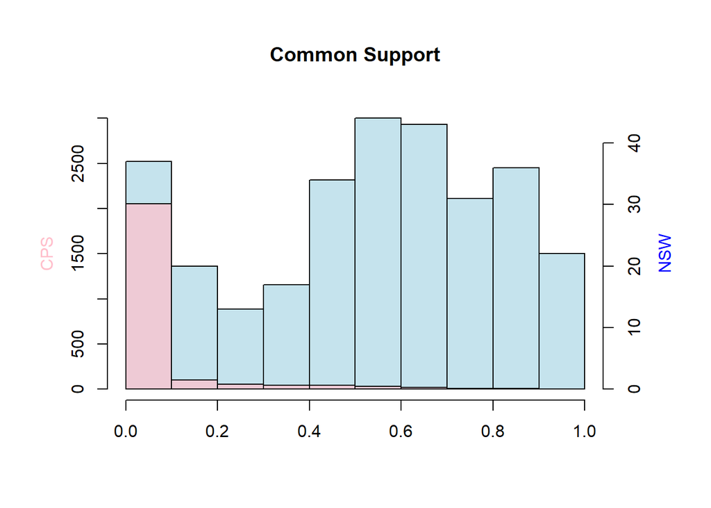

```r
c1 <- rgb(173,216,230,max = 255, alpha = 180, names = "lt.blue")
c2 <- rgb(255,192,203, max = 255, alpha = 180, names = "lt.pink")

par(mar = c(5, 5, 5, 5) + 0.3)
hist(filter(obs_df, treat == 1)$pscore, freq = TRUE, col = c1, axes = FALSE, xlab = "", ylab = "", main = "")
axis(side = 1, xlim = c(0,1))
axis(side = 4, ylab = "")
mtext(side = 4, text = "NSW", line = 2.5, col = "blue")
par(new=TRUE)
hist(filter(obs_df, treat == 0)$pscore, ylim = c(0,3000), freq = TRUE, axes = FALSE, col = c2, xlab = "", ylab = "", main = "Common Support")
axis(side = 2)
mtext(side = 2, text = "CPS", line = 2.5, col = "pink")
```

We see that the control group (the CPS observations) are highly concentrated close to zero. This is because the NSW experiment chose disadvantaged individuals which are not representative of the US population as the CPS is. Hence, we have a comparability issue. A practical solution is to trim the observations with very low (or high) propensity scores. For instance, if we trim observation with a propensity score lower than 0.1 and higher than 0.9 we see the Common Support assumption seems more plausible

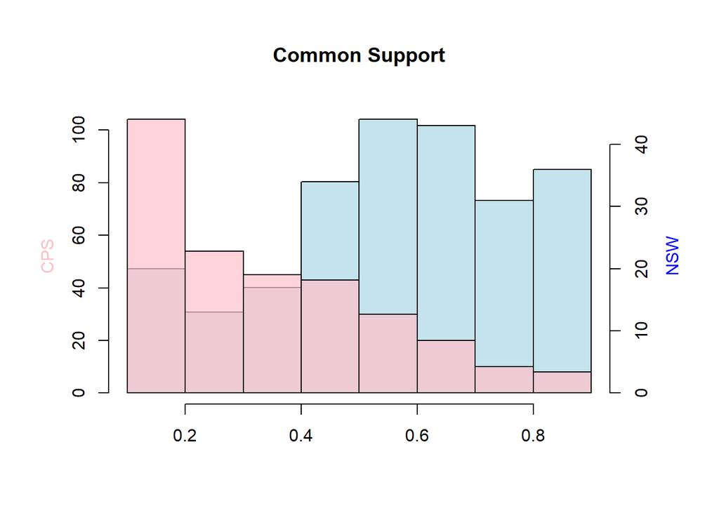

```r
obs_dftrim <- filter(obs_df, pscore > 0.1 & pscore < 0.9)

par(mar = c(5, 5, 5, 5) + 0.3)
hist(filter(obs_dftrim, treat == 1)$pscore, freq = TRUE, col = c1, axes = FALSE, xlab = "", ylab = "", main = "")
axis(side = 1, xlim = c(0,1))
axis(side = 4, ylab = "")
mtext(side = 4, text = "NSW", line = 2.5, col = "blue")
par(new=TRUE)
hist(filter(obs_dftrim, treat == 0)$pscore, freq = TRUE, axes = FALSE, col = c2, xlab = "", ylab = "", main = "Common Support")
axis(side = 2)
mtext(side = 2, text = "CPS", line = 2.5, col = "pink")
```

and the estimates become more stable.

```r
Ytr <- obs_dftrim$re78
Dtr <- obs_dftrim$treat
PStr <- obs_dftrim$pscore

ipw1tr <- mean(Dtr*Ytr/PStr - (1-Dtr)*Ytr/(1-PStr))
ipw2tr <- (1/(sum(Dtr/PStr)))*sum(Dtr*Ytr/PStr) - (1/(sum((1-Dtr)/(1-PStr))))*sum((1-Dtr)*Ytr/(1-PStr))

# Doubly Robust
m1 <- lm(re78 ~ poly(age,2) + education + black + hispanic + nodegree, filter(obs_dftrim,treat == 1))
m1hat <- predict(m1, obs_dftrim)
m0 <- lm(re78 ~ poly(age,2) + education + black + hispanic + nodegree, filter(obs_dftrim,treat == 0))
m0hat <- predict(m0, obs_dftrim)

ipwdrtr <- mean((Dtr*Ytr - (Dtr-PStr)*m1hat)/PStr) - mean(((1-Dtr)*Ytr - (Dtr-PStr)*m0hat)/(1-PStr))
c("IPW1" = ipw1tr, "IPW2" = ipw2tr, "DR" = ipwdrtr)
```

```
##      IPW1      IPW2        DR
## -865.2516 -631.5008 -847.0897
```

For the rest of this exercise let us restrict the sample to these observations

```r
obs_df <- obs_dftrim
PS <- PStr
Y <- Ytr
D <- Dtr
ipw1 <- ipw1tr
ipw2 <- ipw2tr
```

## Inference on IPW

$\hat{\tau}_1^{IPW}$ and $\tau_2^{IPW}$ can be written as Z-estimators. Let us illustrate this for $\hat{\tau}_1^{IPW}$, let $Z_i = (Y_i,D_i,X_i)$ be the data and $\theta_0 = (\tau_0, \beta')'$. Define

$$q(Z_i, \theta) = \begin{pmatrix}
\frac{D_i Y_i}{G(X_i' \beta)} - \frac{(1-D_i)Y_i}{1 - G(X_i'
\beta)} - \tau \\
X_i(D_i - G(X_i'\beta))
\end{pmatrix}$$
$q(Z_i, \theta)$ is a $(k+1) \times 1$ vector function where $k$ is the dimension of $\beta$. The last $k$ elements of $q(Z_i, \theta)$ are the FOCs of the MLE from the Logit model (the score). Then, $\mathbb{E}[q(Z_i, \theta_0)] = 0$ and $(\hat{\tau}^{IPW}_1, \hat{\beta})$ are chosen such that $\sum_{i=1}^n q(Z_i, \hat{\theta}) = 0$. Let $\dot{q}(Z_i, \theta)$ be the matrix of derivatives of $q$ with respect to parameters in $\theta$. By taking a mean value expansion around $\theta_0$ and rearranging we can show that

$$\sqrt{n}(\hat{\theta} - \theta_0) = - \biggl(n^{-1}\sum_{i=1}^n
\dot{q}(Z_i, \bar{\theta})\biggr)^{-1} \biggl(n^{-1/2} \sum_{i=1}^n
q(Z_i, \theta_0) \biggr) \to_d
\mathcal{N}(0,\mathbb{E}[\dot{q}(Z_i,\theta_0)]^{-1} \mathbb{E}[q(Z_i,
\theta_0)^2]\mathbb{E}[\dot{q}(Z_i,\theta_0)]^{-1}),$$

where $\bar{\theta}$ is some intermediate point between $\hat{\theta}$ and $\theta_0$. So we can estimate the variance as

$$\hat{V}_1 = \biggl(n^{-1}\sum_{i=1}^n
\dot{q}(Z_i,\hat{\theta})\biggr)^{-1} \biggl(n^{-1}\sum_{i=1}^nq(Z_i,
\hat{\theta}) q(Z_i, \hat{\theta})' \biggr)
\biggl(n^{-1}\sum_{i=1}^n \dot{q}(Z_i,\hat{\theta})\biggr)^{-1}$$

Noticing that $\frac{d}{d u} G(u) = G(u)(1-G(u))$ we can compute the $(k + 1) \times (k +1)$ matrix $\dot{q}$

$$\dot{q}(Z_i, \theta) = \begin{pmatrix}
-1 &
-X_i'\biggl(\frac{D_iY_i(1-G(X_i'\beta))}{G(X_i'\beta)} -
\frac{(1-D_i)Y_iG(X_i'\beta)}{1-G(X_i' \beta)}\biggr) \\
0 & X_iX_i'G(X_i' \beta)(1-G(X_i'\beta))
\end{pmatrix}$$

So we can estimate the standard error of $\hat{\tau}^{IPW}_1$

```r
obs_df$const <- rep(1,nrow(obs_df))
X <- as.matrix(dplyr::select(obs_df,c(const,age,agesq,education,educationsq,married,
                               re75,re75sq,black,hispanic,nodegree)))
A <- 0
B12 <- 0
B22 <- 0
G <- function(u){exp(u)/(1+exp(u))}
k <- ncol(X)

for (i in 1:nrow(X)){
  aux <-  matrix(c(D[i]*Y[i]/PS[i] - (1-D[i])*Y[i]/(1-PS[i]) - ipw1,
                    X[i,]*(D[i] - PS[i])),k+1,1)
  A <- A + aux%*%t(aux)
  B12 <- B12 - t(X[i,])*((D[i]*Y[i]*(1-PS[i]))/PS[i] + ((1-D[i])*Y[i]*PS[i])/(1-PS[i]))
  B22 <- B22 - (X[i,] %*% t(X[i,]))*(PS[i]*(1-PS[i]))
}
B <- (1/nrow(X))*rbind(cbind(-nrow(X),B12), cbind(rep(0,k),B22))
V <- inv(B) %*% ((1/nrow(X))*A) %*% inv(B)
se <- sqrt(V[1,1]/nrow(X))
c("IPW1" = ipw1, "SE" = se)
```

```
##      IPW1        SE
## -865.2516  529.8508
```

Inference for $\hat{\tau}_2^{IPW}$ and $\hat{\tau}^{DR}$ inference follows similarly by framing the problem as a Z-estimator. With a little tweak in the double robust estimator we can get simpler inference.

## Locally Robust IPW

Note that we can rewrite $\hat{\tau}^{DR}$ as

$$\hat{\tau}^{DR} = \frac{1}{n}\sum_{i=1}^n \biggl( \hat{m}_1(X_i) -
\hat{m}_0(X_i) + \frac{D_i}{\hat{p}(X_i)}[Y_i - \hat{m}_1(X_i)]
- \frac{1-D_i}{1 - \hat{p}(X_i)}[Y_i - \hat{m}_0(X_i)] \biggr).$$

Note that this resembles the direct estimation of the ATE but with an added term, this term is a correction term which ensures local robustness. Now define

$$\psi(Z_i, p, m_1, m_0, \tau) = m_1(X_i) - m_0(X_i) +
\underbrace{\frac{D_i}{p(X_i)}[Y_i - m_1(X_i)] - \frac{(1-D_i)}{1 -
p(X_i)}[Y_i - m_0(X_i)]}_{\phi(Z_i,p,m_1,m_0)} - \tau,$$
and notice that $\hat{\tau}^{DR}$ is the $\tau$ which solves $\sum_{i=1}^n \psi(Z_i, \hat{p}, \hat{m}_1, \hat{m}_0, \tau) = 0$. The $\phi$ function is sometimes called the First Step Influence Function (FSIF, see (Chernozhukov et al. 2022)). As already stated it makes the orthogonal moment function locally robust by capturing the effect of first steps estimation. It turns out that $\psi$ has another very special property: that of an orthogonal moment function. This means that, locally, estimating nuisance functions $p$ $m_1$ and $m_0$ has no impact. In fact we can even estimate them non-parametrically under mild rate conditions. Modifying slightly the estimator to estimate $p$, $m_1$ and $m_0$ with observations different from the ones we use to estimate $\tau_0$ (this is called cross-fitting) allows us to avoid over-fitting, use many non-parametric estimators such as machine learners and provide valid inference based only on the orthogonal moment function $\psi$. Hence, we define the locally robust IPW estimator as a cross-fitted version of the above. Partition the observations in $L$ sets denoted by $I_1,...,I_L$, then

$$\hat{\tau}^{LR} = \frac{1}{n} \sum_{l=1}^L \sum_{i \in I_l}
\biggl(\hat{m}_{1,l}(X_i) - \hat{m}_{0,l}(X_i) +
\frac{D_i}{\hat{p}_l(X_i)}[Y_i - \hat{m}_{1,l}(X_i)] - \frac{(1-D_i)}{1
- \hat{p}_l(X_i)}[Y_i - \hat{m}_{0,l}(X_i)] \biggr)$$
To estimate it we split the data in two.

```r
set.seed(123)
n <- nrow(obs_df)
L <- 2
ind <- split(seq(n), seq(n) %% L)

fv1 <- rep(0,n)
fv0 <- rep(0,n)
ps <- rep(0,n)
for (i in 1:L){
  mps <- ranger(treat ~ age + agesq + education + educationsq + married + re75 + re75sq + black +
                   hispanic + nodegree, data = obs_df[ind[[i]],])
  mfv1 <- ranger(re78 ~ treat + age + agesq + education + black + hispanic + nodegree,
                data = filter(obs_df[ind[[i]],], treat == 1))
  mfv0 <- ranger(re78 ~ treat + age + agesq + education + black + hispanic + nodegree,
                data = filter(obs_df[ind[[i]],], treat == 0))

  fv1[-ind[[i]]] <- predict(mfv1, obs_df[-ind[[i]],])$predictions
  fv0[-ind[[i]]] <- predict(mfv0, obs_df[-ind[[i]],])$predictions
  ps[-ind[[i]]] <- predict(mps, obs_df[-ind[[i]],])$predictions

}

ipwlr_sc <- fv1 - fv0 + (D/ps)*(Y-fv1) - ((1-D)/(1-ps))*(Y-fv0)
ipwlr <- mean(ipwlr_sc)
se_lr <- sd(ipwlr_sc)/sqrt(n)
c(ipwlr = ipwlr, se = se_lr)
```

```
##     ipwlr        se
## -703.2693  847.9069
```

We still get a negative effect and very large standard errors. In general this data seems to be very ill suited for estimating treatment effects since the controls are wildly different from the treated.

## Packages and other sources

For a book on treatment effects one can read (Angrist and Pischke 2009), for a reference on IPW is a good reference is (Lunceford and Davidian 2004). The theory of the logistic regression is that of the conditional MLE and can be found for instance in (Wooldridge 2002). A similar tutorial to this can be found [here](https://bookdown.org/halflearned/tutorial/ate1.html#aipw-estimators). Also, there are several packages with functions to perform the above estimation. An example of such a package is [PSweight](https://arxiv.org/pdf/2010.08893.pdf) in (Zhou et al. 2020) where the package is compared to other similar packages.

# References

Angrist, Joshua D, and Jörn-Steffen Pischke. 2009. *Mostly Harmless Econometrics: An Empiricist’s Companion*. Princeton university press.

Chernozhukov, Victor, Juan Carlos Escanciano, Hidehiko Ichimura, Whitney K Newey, and James M Robins. 2022. “Locally Robust Semiparametric Estimation.” *Econometrica* 90 (4): 1501–35.

Dehejia, Rajeev H, and Sadek Wahba. 1999. “Causal Effects in Nonexperimental Studies: Reevaluating the Evaluation of Training Programs.” *Journal of the American Statistical Association* 94 (448): 1053–62.

LaLonde, Robert J. 1986. “Evaluating the Econometric Evaluations of Training Programs with Experimental Data.” *The American Economic Review*, 604–20.

Lunceford, Jared K, and Marie Davidian. 2004. “Stratification and Weighting via the Propensity Score in Estimation of Causal Treatment Effects: A Comparative Study.” *Statistics in Medicine* 23 (19): 2937–60.

Robins, James M, Andrea Rotnitzky, and Lue Ping Zhao. 1994. “Estimation of Regression Coefficients When Some Regressors Are Not Always Observed.” *Journal of the American Statistical Association* 89 (427): 846–66.

Wooldridge, Jeffrey M. 2002. “Econometric Analysis of Cross Section and Panel Data MIT Press.” *Cambridge, MA* 108 (2): 245–54.

Zhou, Tianhui, Guangyu Tong, Fan Li, and Laine E Thomas. 2020. “PSweight: An r Package for Propensity Score Weighting Analysis.” *arXiv Preprint arXiv:2010.08893*.